# Practical Machine Learning

*Analysis by kateetak - Performed on 22th of January 2015*

### Synopsis - Summary

The analysis studies different models based on the data provided by the project and select the best one to be applied to the test data to calculate its acccuracy.

The selected model is a tree forest model applied to reduced set of features highlighted to be the important features for the data.

The accuracy level of the model applied to the test data is close to 1.

### Exploratory data analysis

After loading the data a basic exploratory data analysis is performed to understand the distribution of the classes on the training data set. The results in the table below show that 28% of the observations are of class A, while the remaining data are almost evenly distributed across the remaining classes.

```
##  Classe Frequency
##       A      0.28
##       B      0.19
##       C      0.17
##       D      0.16
##       E      0.18
```

### Cleaning the data

The dataset is big and the original number of features is equal to 160. Therefor some additional analysis has been performed to reduce the number of features to the ones required and significant for the model. In particular:

- 43 near zero values columns are excluded and will reduce the dataset to 117 variables;
- 58 columns are excluded because they mainly contain NA values. It has been calculated that the columns with at least one NA value all contain 19216 NAs out of 19622 observation, this means that .98 of each observation in that columns are NAs. By removing these columns the dataset only contains 59 features (including the classe column).
- the first 6 columns, containing descriptive values, are not relevant for the analysis and are therefore removed. These columns are the id of the observation, the user_name, the timestamps and the num_window.

The following list shows the list of the 52 features used for the models below.

```
##  [1] "roll_belt"            "pitch_belt"           "yaw_belt"
##  [4] "total_accel_belt"     "gyros_belt_x"         "gyros_belt_y"
##  [7] "gyros_belt_z"         "accel_belt_x"         "accel_belt_y"
## [10] "accel_belt_z"         "magnet_belt_x"        "magnet_belt_y"
## [13] "magnet_belt_z"        "roll_arm"             "pitch_arm"
## [16] "yaw_arm"              "total_accel_arm"      "gyros_arm_x"
## [19] "gyros_arm_y"          "gyros_arm_z"          "accel_arm_x"
## [22] "accel_arm_y"          "accel_arm_z"          "magnet_arm_x"
## [25] "magnet_arm_y"         "magnet_arm_z"         "roll_dumbbell"
## [28] "pitch_dumbbell"       "yaw_dumbbell"         "total_accel_dumbbell"
## [31] "gyros_dumbbell_x"     "gyros_dumbbell_y"     "gyros_dumbbell_z"
## [34] "accel_dumbbell_x"     "accel_dumbbell_y"     "accel_dumbbell_z"
## [37] "magnet_dumbbell_x"    "magnet_dumbbell_y"    "magnet_dumbbell_z"
## [40] "roll_forearm"         "pitch_forearm"        "yaw_forearm"
## [43] "total_accel_forearm"  "gyros_forearm_x"      "gyros_forearm_y"
## [46] "gyros_forearm_z"      "accel_forearm_x"      "accel_forearm_y"
## [49] "accel_forearm_z"      "magnet_forearm_x"     "magnet_forearm_y"
## [52] "magnet_forearm_z"     "classe"
```

The last feature in the list (classe) is the value to be predicted.

### Practical Machine Learning

#### Data Partition

The data are partitioned using a *p=0.3* value, this will result in a training set smaller than the testing set (this is not the standard rule to be applied when performing a data partition but will allow a reasonable processing time).

The size of the training and test set is:

```
##  training testing
##      5889   13733
```

### Model fitting

#### First model - tree prediction

The first model analyzed uses a tree prediction through the rpart method.

However the confusion matrix for this model shows a very low *accuracy equal to only 0.582*. Even if this model has the advantage to be fast in the processing compared to the others (even on bigger training partitions), the values predicted are not accurate so further models are evaluated.

#### Second model - Random forest prediction

A random forest model is tested and the accuracy is very high. However this model takes a long time to process, with the selected training set with p=0.3 at least 15 minutes are required to retrieve it.

#### Third model - Random forest prediction with Top20 features

A further model fitting is performed to check if it is possible to achieve good performances in the model calculation with a standard approach in the data partition between training and test data.

The approach selected is to reduce the number of features selected to the ones that are move important. This is achieved by using the **varImp** function.

The following plot shows the importance of the variables on the Random forest model.

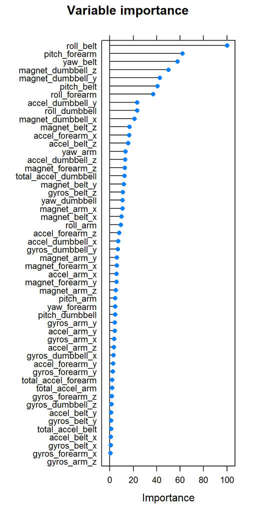

The following table shows the Top20 features selected and their importance value, these are the only features used to obtain the third model.

```
##                 feature  value
## 1             roll_belt 100.00
## 41        pitch_forearm  61.92
## 3              yaw_belt  57.56
## 39    magnet_dumbbell_z  50.04
## 38    magnet_dumbbell_y  42.68
## 2            pitch_belt  40.74
## 40         roll_forearm  37.01
## 35     accel_dumbbell_y  23.17
## 27        roll_dumbbell  23.14
## 37    magnet_dumbbell_x  20.88
## 13        magnet_belt_z  16.81
## 47      accel_forearm_x  16.45
## 10         accel_belt_z  15.64
## 16              yaw_arm  13.17
## 36     accel_dumbbell_z  13.08
## 52     magnet_forearm_z  12.77
## 30 total_accel_dumbbell  12.45
## 12        magnet_belt_y  11.96
## 7          gyros_belt_z  11.10
## 29         yaw_dumbbell  10.78
```

The data are partitioned using a *p=0.7* value (which is the recommended value).

The dimension of the resulting training and test data is the following:

```
##  training testing
##     13737    5885
```

#### Model comparison

The following figure shows a comparison between the **confusion matrix** for the Tree model and the Random forest model:

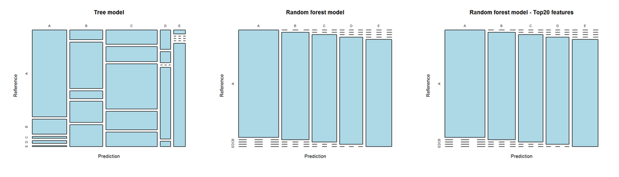

From the picture it is visible that the predicted values and the observed one on the training set match in the Random forest model (on the right), while they are often different in the Tree model (on the left).

The value of the **accuracy** of the models on the training data is shown in the following table:

```
##                        Model Accuracy
##                   Tree model   0.5819
##          Random forest model   1.0000
##  Random forest model - Top20   1.0000
```

#### Model selection

The **Random forest model - Top20** is selected because it meets the accuracy criteria, the speed to compute it is fast enough and it can be calculated on a bigger amount (70%) of the available data.

### Cross validation

The cross validation has been performed by predicting the values in the test set with the selected model and comparing them with the observed values.

The accuracy on the test set is high confirming the accuracy of the model:

```
## Accuracy
##   0.9883
```

### Appendix

#### Prediction on the course project submission

The following shows the predicted values and their probability on the testing data using the selected model:

```
##    Value    %A    %B    %C    %D    %E
## 1      B 0.216 0.662 0.090 0.026 0.006
## 2      A 0.936 0.032 0.028 0.002 0.002
## 3      B 0.052 0.810 0.096 0.002 0.040
## 4      A 0.812 0.010 0.106 0.066 0.006
## 5      A 0.938 0.022 0.038 0.000 0.002
## 6      E 0.008 0.116 0.204 0.024 0.648
## 7      D 0.014 0.020 0.080 0.872 0.014
## 8      B 0.084 0.626 0.068 0.186 0.036
## 9      A 0.988 0.010 0.000 0.000 0.002
## 10     A 0.992 0.008 0.000 0.000 0.000
## 11     B 0.066 0.700 0.074 0.100 0.060
## 12     C 0.026 0.116 0.778 0.016 0.064
## 13     B 0.004 0.970 0.008 0.006 0.012
## 14     A 1.000 0.000 0.000 0.000 0.000
## 15     E 0.010 0.042 0.008 0.024 0.916
## 16     E 0.008 0.016 0.002 0.014 0.960
## 17     A 0.948 0.002 0.000 0.000 0.050
## 18     B 0.186 0.596 0.012 0.194 0.012
## 19     B 0.212 0.740 0.012 0.026 0.010
## 20     B 0.002 0.998 0.000 0.000 0.000
```

*Note:* this is the prediction on the course project submission